# Midterm project Crime data

Team 5

2022-11-02

# Crime Data in DC area

```r
library(ggplot2)
library(ezids)
library(dplyr)
library(readr)
```

### read data

Read the data .CSV files of adults arrest in DC area from 2016-2021

```r
df_2016<-data.frame(read.csv("Arrests 2016 Public.csv"))[,1:14]
df_2017<-data.frame(read.csv("Arrests 2017 Public.csv"))[,1:14]
df_2018<-data.frame(read.csv("Arrests by Year, 2018.csv"))[,1:14]
df_2019<-data.frame(read.csv("Arrests by Year, 2019.csv"))[,1:14]
df_2020<-data.frame(read.csv("Arrests by Year 2020.csv"))[,1:14]
df_2021<-data.frame(read.csv("2021 Adult Arrests.csv"))[,1:14]
```

Note that the colnames of df_2016 and df_2017 are not the same with others. But those indices are just about arrest location which is not what we are investigating. Therefore I just combined them by the same indices that we need. (A-N columns) ##Merge Multiple CSV Files bind by rows

```r
DF<-rbind(df_2016,df_2017,df_2018,df_2019,df_2020,df_2021)
#colnames(DF)
xkablesummary(DF)
```

colnames

```r
colnames(DF)
```

### Sort data

**There is no outliers, since our observations are not values, just all nominals**

find NaN

```r
sum_age<-sum(is.nan(DF$Age))
sum_year<-sum(is.nan(DF$Arrest.Year))
sum_race<-sum(is.nan(DF$Defendant.Race))
sum_sex<-sum(is.nan(DF$Defendant.Sex))
sum_category<-sum(is.nan(DF$Arrest.Category))
sum_nan<-sum_age+sum_race+sum_sex+sum_category+sum_year
sum_nan
```

(There is too many *“unknown”*in defendant Ethnicity, so I think it is ok that we consider only the Defendant Race) The sum of NaN in the columns of interest (**“Year”**,**“Age”**, **“Defendant race/sex”**, **“Arrest Category”**) is 0

factor by years

```r
#DF
#DF[,2] = as.factor(DF$Arrest.Year)
#DF[,10] = as.factor(DF$Defendant.Race)
#DF[,12] = as.factor(DF$Defendant.Sex)
#DF[,13] = as.factor(DF$Defendant.Category)
head(DF)
```

Age distribution

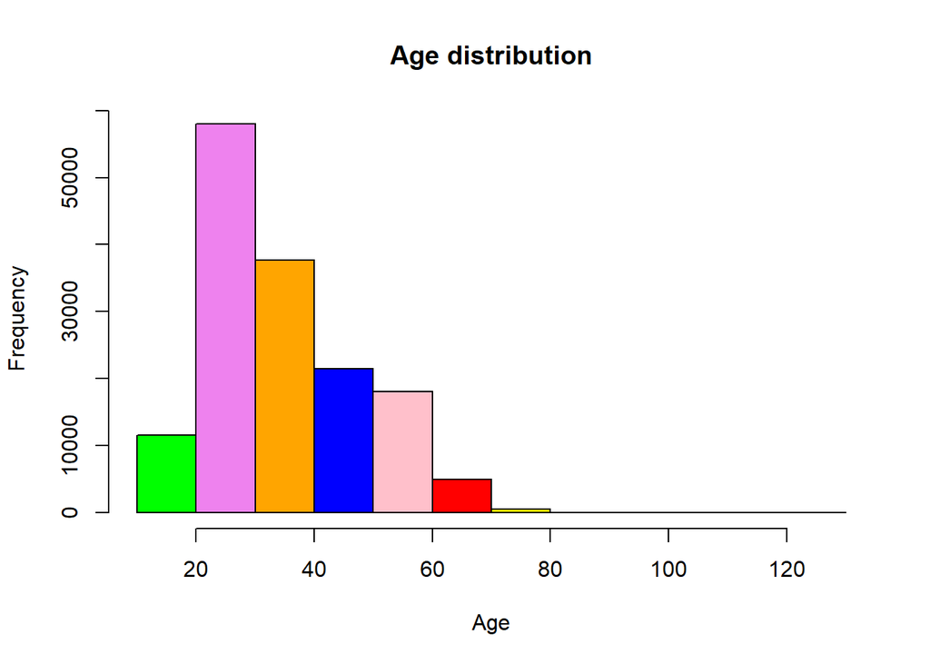

```r
barcolors = c("green", "violet", "orange", "blue", "pink", "red", "yellow", "cyan")

hist(DF$Age, main = "Age distribution",  col=barcolors,xlab="Age", breaks = 10)
```

```r
ttest95_age = t.test(x=DF$Age, conf.level=0.95 )
#ttest95_age$conf.int
```

The T-test(95%) for **“Age”** is 35.128, 35.255`

The trend of the **Total Crimes** between 2016-2021

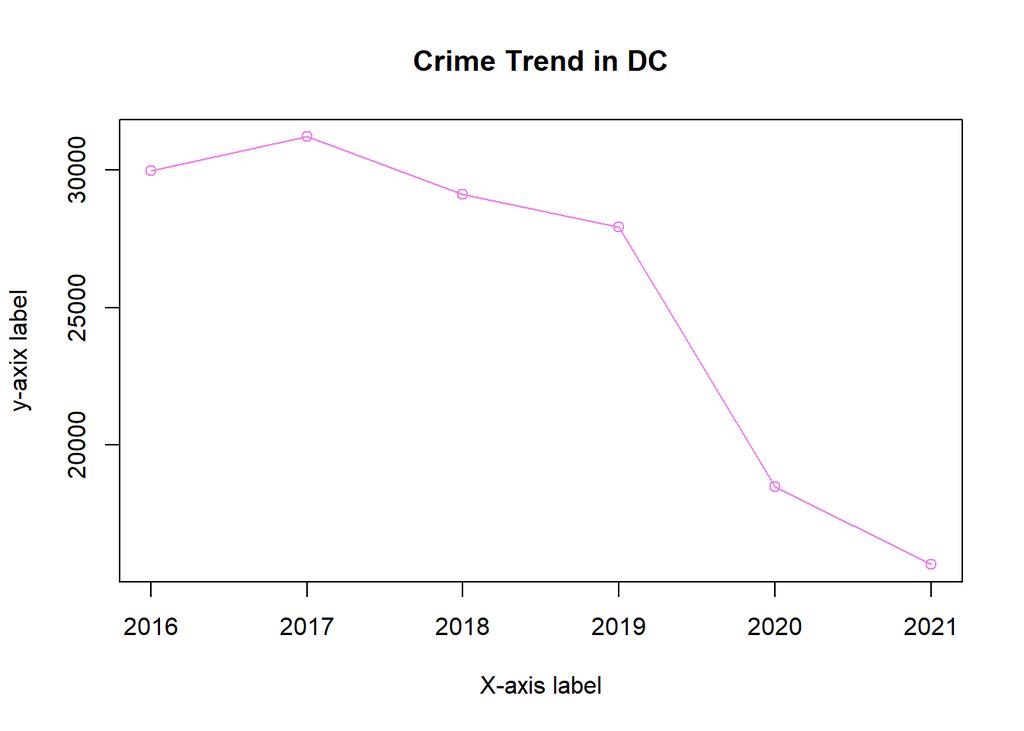

```r
plot(c(seq(2016, 2021, by=1)),c(nrow(df_2016),nrow(df_2017),nrow(df_2018),nrow(df_2019),nrow(df_2020),nrow(df_2021)), xlab="X-axis label", ylab="y-axix label",col='violet',type='o',lwd=1,lty=1)
title(main ="Crime Trend in DC")
```

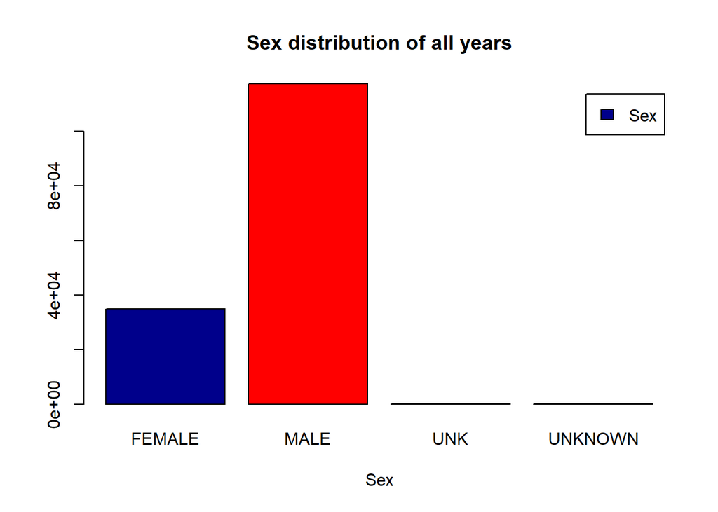

```r
counts <- table(DF$Defendant.Sex)
barplot(counts, main="Sex distribution of all years",
  xlab="Sex", col=c("darkblue","red"),
  legend = c("Sex"), beside=TRUE)
```

Drop the rows with “uknown(UNK)” and “FEMALE”, since we are focus only on **“MALE”** crimes.

```r
xx<-which(DF$Defendant.Sex == "UNK")
xxx<-which(DF$Defendant.Sex == "UNKNOWN")
xxxx<-which(DF$Defendant.Sex == "FEMALE")
DF2<- DF[-c(xx,xxx,xxxx), ]
head(DF2)[,10:14]
```

**Race distribtion**

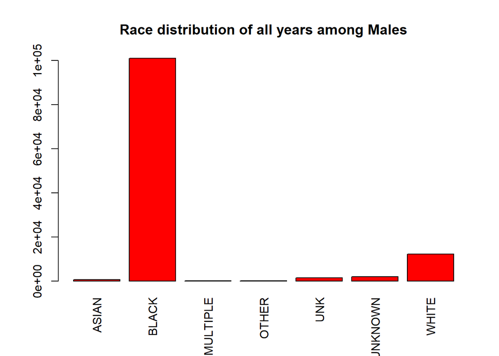

```r
counts <- table(DF2$Defendant.Race)
barplot(counts,las=3,names.arg = names(counts), main="Race distribution of all years among Males", col=c("red"),
  beside=TRUE)
```

**Compared with “black” and “white”, the rest of the races take over only a small proportion of the sample, which is too samll to do analysis, so we drop them**

I know we are focusing only white men, but**I keep both black and white for now**

```r
yy<-which(DF2$Defendant.Race == "BLACK")
yyy<-which(DF2$Defendant.Race == "WHITE")
DF3<- DF2[c(yy,yyy), ]
tail(DF3)[,2:6]
```

```r
#barplot(table(DF3$Arrest.Year=="2021"))
```

**Distibution of crime type (Arrest.Category)**

There are plenty of crime categories, we only do analysis of the top crimes.

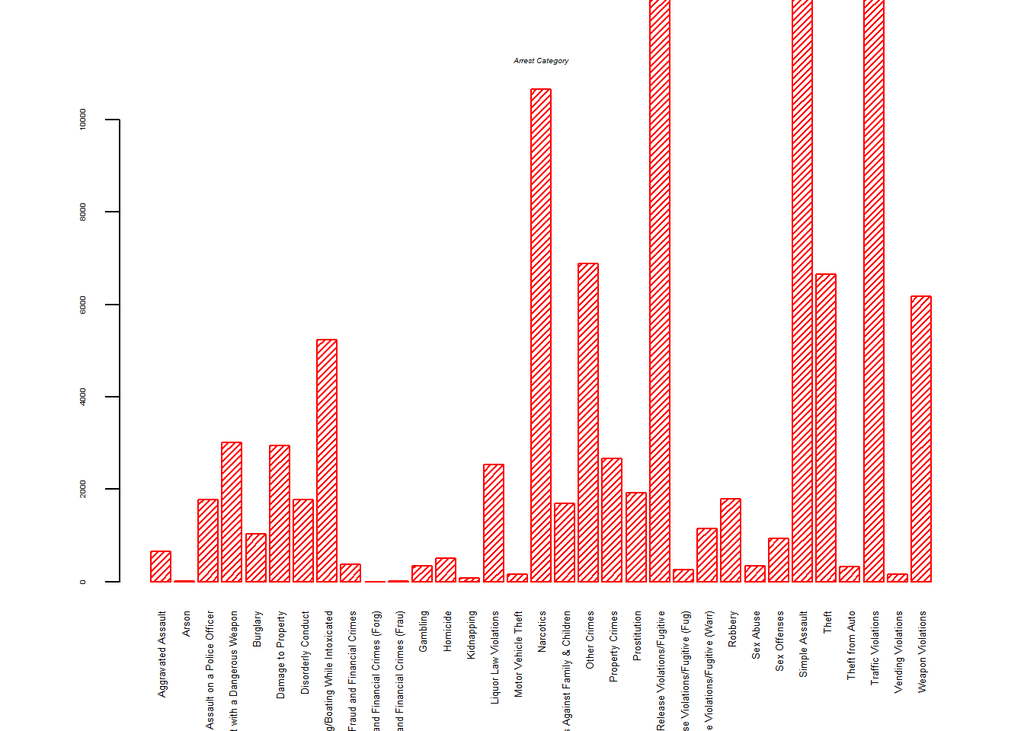

```r
counts_cat <- table(DF3$Arrest.Category)
barplot(counts_cat,las=3,names.arg = names(counts_cat),cex.names=0.4, main="Arrest Category", col=c("red"),density = 32,angle = 45,border = TRUE, plot = TRUE,cex.main=0.3,cex.axis = 0.3,font.main=3,ylim=c(0, 10000))
```

category by years

```r
DF_2016<- DF3[DF3$Arrest.Year == "2016", ]
DF_2017 <- DF3[DF3$Arrest.Year == "2017", ]
DF_2018 <- DF3[DF3$Arrest.Year == "2018", ]
DF_2019 <- DF3[DF3$Arrest.Year == "2019", ]
DF_2020 <- DF3[DF3$Arrest.Year == "2020", ]
DF_2021 <- DF3[DF3$Arrest.Year == "2021", ]
```

### Crime distribution

filter the top crimes of every year

```r
#df_ls<-list("DF_2016","DF_2017","DF_2018","DF_2019","DF_2020","DF_2021")
#top_crime_ls<-list(x = 1:6)
#for( i in 1:6){
#  counts_cat_tmp <- table(df_ls[i]$Arrest.Category)
#  pos_tmp<-order(counts_cat_tmp ,decreasing=TRUE)[1:6]
#  top_crime_ls[i]<-names(counts_cat_tmp)[pos]}

#2016 top
cnt_2016<-table(DF_2016$Arrest.Category)
pos_2016<-order(cnt_2016,decreasing=TRUE)[1:6]
crime_2016<-names(cnt_2016)[pos_2016]
#2017 top
cnt_2017<-table(DF_2017$Arrest.Category)
pos_2017<-order(cnt_2017,decreasing=TRUE)[1:6]
crime_2017<-names(cnt_2017)[pos_2017]
#2018 top
cnt_2018<-table(DF_2018$Arrest.Category)
pos_2018<-order(cnt_2018,decreasing=TRUE)[1:6]
crime_2018<-names(cnt_2018)[pos_2018]
#2019 top
cnt_2019<-table(DF_2019$Arrest.Category)
pos_2019<-order(cnt_2019,decreasing=TRUE)[1:6]
crime_2019<-names(cnt_2019)[pos_2019]
#2020 top
cnt_2020<-table(DF_2020$Arrest.Category)
pos_2020<-order(cnt_2020,decreasing=TRUE)[1:6]
crime_2020<-names(cnt_2020)[pos_2020]
#2021 top
cnt_2021<-table(DF_2021$Arrest.Category)
pos_2021<-order(cnt_2021,decreasing=TRUE)[1:6]
crime_2021<-names(cnt_2021)[pos_2021]
```

The top several crime among “white(and black)” males of every year is 2016 Simple Assault, Release Violations/Fugitive, Traffic Violations, Narcotics, Theft, Other Crimes`

2017 **Simple Assault, Release Violations/Fugitive, Traffic Violations, Narcotics, Other Crimes, Theft**

2018 **Simple Assault, Release Violations/Fugitive, Traffic Violations, Narcotics, Theft, Other Crimes**

2019 **Simple Assault, Traffic Violations, Release Violations/Fugitive, Narcotics, Theft, Other Crimes**

2020 **Simple Assault, Release Violations/Fugitive, Traffic Violations, Weapon Violations, Narcotics, Other Crimes**

2021 **Simple Assault, Release Violations/Fugitive (Warr), Weapon Violations, Traffic Violations, Other Crimes, Driving/Boating While Intoxicated**

### Crime trend for specific category

#### Make a new dataframe to collect the counts of the crimes of interest of all years among white males

Note: 1. I don’t know if we are supposed to consider “Other Crimes”, cause IDK how to explain it. I added it for now 2. I added “Theft” “Narcotics”, though they don’t appear in top 6 in every year,they still account for a significant proportion

code for creating a new dataframe

```r
#WHITE "Simple Assault"
SIM_WHITE<-list()

SIM_WHITE<-table(DF_2016$Arrest.Category[DF_2016$Defendant.Race=="WHITE"]=="Simple Assault")["TRUE"]%>%sum()%>%append(SIM_WHITE,. )

SIM_WHITE<-table(DF_2017$Arrest.Category[DF_2017$Defendant.Race=="WHITE"]=="Simple Assault")["TRUE"]%>%sum()%>%append(SIM_WHITE,. )

SIM_WHITE<-table(DF_2018$Arrest.Category[DF_2018$Defendant.Race=="WHITE"]=="Simple Assault")["TRUE"]%>%sum()%>%append(SIM_WHITE,. )

SIM_WHITE<-table(DF_2019$Arrest.Category[DF_2019$Defendant.Race=="WHITE"]=="Simple Assault")["TRUE"]%>%sum()%>%append(SIM_WHITE,. )

SIM_WHITE<-table(DF_2020$Arrest.Category[DF_2020$Defendant.Race=="WHITE"]=="Simple Assault")["TRUE"]%>%sum()%>%append(SIM_WHITE,. )

SIM_WHITE<-table(DF_2021$Arrest.Category[DF_2021$Defendant.Race=="WHITE"]=="Simple Assault")["TRUE"]%>%sum()%>%append(SIM_WHITE, .)

SIM_WHITE<-c(SIM_WHITE[[1]],SIM_WHITE[[2]],SIM_WHITE[[3]],SIM_WHITE[[4]],SIM_WHITE[[5]],SIM_WHITE[[6]])
```

```r
#Release Violations/Fugitive
RVF_WHITE<-list()

RVF_WHITE<-table(DF_2016$Arrest.Category[DF_2016$Defendant.Race=="WHITE"]=="Release Violations/Fugitive")["TRUE"]%>%sum()%>%append(RVF_WHITE, .)

RVF_WHITE<-table(DF_2017$Arrest.Category[DF_2017$Defendant.Race=="WHITE"]=="Release Violations/Fugitive")["TRUE"]%>%sum()%>%append(RVF_WHITE,. )

RVF_WHITE<-table(DF_2018$Arrest.Category[DF_2018$Defendant.Race=="WHITE"]=="Release Violations/Fugitive")["TRUE"]%>%sum()%>%append(RVF_WHITE,. )

RVF_WHITE<-table(DF_2019$Arrest.Category[DF_2019$Defendant.Race=="WHITE"]=="Release Violations/Fugitive")["TRUE"]%>%sum()%>%append(RVF_WHITE,. )

RVF_WHITE<-table(DF_2020$Arrest.Category[DF_2020$Defendant.Race=="WHITE"]=="Release Violations/Fugitive")["TRUE"]%>%sum()%>%append(RVF_WHITE,. )

RVF_WHITE<-table(DF_2021$Arrest.Category[DF_2021$Defendant.Race=="WHITE"]=="Release Violations/Fugitive (Warr)")["TRUE"]%>%sum()%>%append(RVF_WHITE,. )

RVF_WHITE<-c(RVF_WHITE[[1]],RVF_WHITE[[2]],RVF_WHITE[[3]],RVF_WHITE[[4]],RVF_WHITE[[5]],RVF_WHITE[[6]])
```

```r
#Traffic Violations
TRA_WHITE<-list()

TRA_WHITE<-table(DF_2016$Arrest.Category[DF_2016$Defendant.Race=="WHITE"]=="Traffic Violations")["TRUE"]%>%sum()%>%append(TRA_WHITE,. )

TRA_WHITE<-table(DF_2017$Arrest.Category[DF_2017$Defendant.Race=="WHITE"]=="Traffic Violations")["TRUE"]%>%sum()%>%append(TRA_WHITE,. )

TRA_WHITE<-table(DF_2018$Arrest.Category[DF_2018$Defendant.Race=="WHITE"]=="Traffic Violations")["TRUE"]%>%sum()%>%append(TRA_WHITE,. )

TRA_WHITE<-table(DF_2019$Arrest.Category[DF_2019$Defendant.Race=="WHITE"]=="Traffic Violations")["TRUE"]%>%sum()%>%append(TRA_WHITE,. )

TRA_WHITE<-table(DF_2020$Arrest.Category[DF_2020$Defendant.Race=="WHITE"]=="Traffic Violations")["TRUE"]%>%sum()%>%append(TRA_WHITE,. )

TRA_WHITE<-table(DF_2021$Arrest.Category[DF_2021$Defendant.Race=="WHITE"]=="Traffic Violations")["TRUE"]%>%sum()%>%append(TRA_WHITE, .)

TRA_WHITE<-c(TRA_WHITE[[1]],TRA_WHITE[[2]],TRA_WHITE[[3]],TRA_WHITE[[4]],TRA_WHITE[[5]],TRA_WHITE[[6]])
```

```r
#Narcotics
NAR_WHITE<-list()

NAR_WHITE<-table(DF_2016$Arrest.Category[DF_2016$Defendant.Race=="WHITE"]=="Narcotics")["TRUE"]%>%sum()%>%append(NAR_WHITE,. )

NAR_WHITE<-table(DF_2017$Arrest.Category[DF_2017$Defendant.Race=="WHITE"]=="Narcotics")["TRUE"]%>%sum()%>%append(NAR_WHITE,. )

NAR_WHITE<-table(DF_2018$Arrest.Category[DF_2018$Defendant.Race=="WHITE"]=="Narcotics")["TRUE"]%>%sum()%>%append(NAR_WHITE, .)

NAR_WHITE<-table(DF_2019$Arrest.Category[DF_2019$Defendant.Race=="WHITE"]=="Narcotics")["TRUE"]%>%sum()%>%append(NAR_WHITE,. )

NAR_WHITE<-table(DF_2020$Arrest.Category[DF_2020$Defendant.Race=="WHITE"]=="Narcotics")["TRUE"]%>%sum()%>%append(NAR_WHITE, .)

NAR_WHITE<-table(DF_2021$Arrest.Category[DF_2021$Defendant.Race=="WHITE"]=="Narcotics")["TRUE"]%>%sum()%>%append(NAR_WHITE, .)

NAR_WHITE<-c(NAR_WHITE[[1]],NAR_WHITE[[2]],NAR_WHITE[[3]],NAR_WHITE[[4]],NAR_WHITE[[5]],NAR_WHITE[[6]])
```

```r
#Theft
THEFT_WHITE<-list()

THEFT_WHITE<-table(DF_2016$Arrest.Category[DF_2016$Defendant.Race=="WHITE"]=="Theft")["TRUE"]%>%sum()%>%append(THEFT_WHITE,. )

THEFT_WHITE<-table(DF_2017$Arrest.Category[DF_2017$Defendant.Race=="WHITE"]=="Theft")["TRUE"]%>%sum()%>%append(THEFT_WHITE,. )

THEFT_WHITE<-table(DF_2018$Arrest.Category[DF_2018$Defendant.Race=="WHITE"]=="Theft")["TRUE"]%>%sum()%>%append(THEFT_WHITE, .)

THEFT_WHITE<-table(DF_2019$Arrest.Category[DF_2019$Defendant.Race=="WHITE"]=="Theft")["TRUE"]%>%sum()%>%append(THEFT_WHITE, .)

THEFT_WHITE<-table(DF_2020$Arrest.Category[DF_2020$Defendant.Race=="WHITE"]=="Theft")["TRUE"]%>%sum()%>%append(THEFT_WHITE,. )

THEFT_WHITE<-table(DF_2021$Arrest.Category[DF_2021$Defendant.Race=="WHITE"]=="Theft")["TRUE"]%>%sum()%>%append(THEFT_WHITE,. )

THEFT_WHITE<-c(THEFT_WHITE[[1]],THEFT_WHITE[[2]],THEFT_WHITE[[3]],THEFT_WHITE[[4]],THEFT_WHITE[[5]],THEFT_WHITE[[6]])
```

```r
#Other Crimes
OTH_WHITE<-list()

OTH_WHITE<-table(DF_2016$Arrest.Category[DF_2016$Defendant.Race=="WHITE"]=="Other Crimes")["TRUE"]%>%sum()%>%append(OTH_WHITE,. )

OTH_WHITE<-table(DF_2017$Arrest.Category[DF_2017$Defendant.Race=="WHITE"]=="Other Crimes")["TRUE"]%>%sum()%>%append(OTH_WHITE, .)

OTH_WHITE<-table(DF_2018$Arrest.Category[DF_2018$Defendant.Race=="WHITE"]=="Other Crimes")["TRUE"]%>%sum()%>%append(OTH_WHITE,. )

OTH_WHITE<-table(DF_2019$Arrest.Category[DF_2019$Defendant.Race=="WHITE"]=="Other Crimes")["TRUE"]%>%sum()%>%append(OTH_WHITE,. )

OTH_WHITE<-table(DF_2020$Arrest.Category[DF_2020$Defendant.Race=="WHITE"]=="Other Crimes")["TRUE"]%>%sum()%>%append(OTH_WHITE,. )

OTH_WHITE<-table(DF_2021$Arrest.Category[DF_2021$Defendant.Race=="WHITE"]=="Other Crimes")["TRUE"]%>%sum()%>%append(OTH_WHITE,.)

OTH_WHITE<-c(OTH_WHITE[[1]],OTH_WHITE[[2]],OTH_WHITE[[3]],OTH_WHITE[[4]],OTH_WHITE[[5]],OTH_WHITE[[6]])
```

This is the DataFrame of top crimes among white males, colnames are **“Simple Assault”, “Release Violations/Fugitive”, “Traffic Violations”, “Narcotics”, “Theft”, “Other Crimes”**

```r
x_year<-c(seq(2016, 2021, by=1))

DF_white<-data.frame(x_year,SIM_WHITE,RVF_WHITE,TRA_WHITE,NAR_WHITE,THEFT_WHITE,OTH_WHITE)
DF_white
#xkablesummary(DF_white)
```

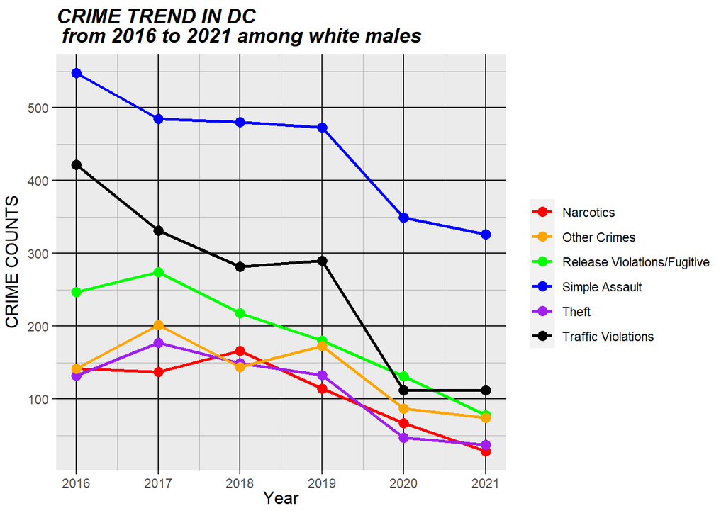

```r
library(ggplot2)

#color_ls<-list("darkorange","darkorange1","darkorange2","darkorange3","darkorange4","darkolivegreen4")
ggplot()+geom_line(data = DF_white,aes(x = x_year,y = SIM_WHITE,colour = "Simple Assault"),size=1)+
  geom_point(data =  DF_white,aes(x = x_year,y = SIM_WHITE,colour = "Simple Assault"),size=3)+

  geom_line(data =  DF_white,aes(x = x_year,y = RVF_WHITE,colour ="Release Violations/Fugitive"),size=1) +
  geom_point(data =  DF_white,aes(x = x_year,y = RVF_WHITE,colour = "Release Violations/Fugitive"),size=3)+

  geom_line(data =  DF_white,aes(x = x_year,y = TRA_WHITE,colour ="Traffic Violations"),size=1) +
  geom_point(data =  DF_white,aes(x = x_year,y = TRA_WHITE,colour = "Traffic Violations"),size=3)+

  geom_line(data =  DF_white,aes(x = x_year,y = NAR_WHITE,colour ="Narcotics"),size=1) +
  geom_point(data =  DF_white,aes(x = x_year,y = NAR_WHITE,colour = "Narcotics"),size=3)+

  geom_line(data =  DF_white,aes(x = x_year,y = THEFT_WHITE,colour ="Theft"),size=1) +
  geom_point(data =  DF_white,aes(x = x_year,y = THEFT_WHITE,colour = "Theft"),size=3)+

  geom_line(data =  DF_white,aes(x = x_year,y =OTH_WHITE,colour ="Other Crimes"),size=1) +
  geom_point(data =  DF_white,aes(x = x_year,y = OTH_WHITE,colour = "Other Crimes"),size=3)+

  scale_colour_manual("",values = c("red","orange","green","blue","purple","black"))+
  xlab("Year")+ylab("CRIME COUNTS")+ ggtitle("CRIME TREND IN DC \n from 2016 to 2021 among white males")+
  theme(plot.title = element_text(lineheight = .8,size = 14, face = "bold.italic"))+
  theme(axis.title.x = element_text(vjust = 2, size = 12),
        axis.title.y = element_text(vjust = 2, size = 12))+
 theme(panel.grid.major = element_line(color = "gray10", size = .5),
        panel.grid.minor = element_line(color = "gray70", size = .25))
```

```r
DF_white_new<-DF_white
colnames(DF_white_new)[2:7]=c("Simple Assault","Release Violations/Fugitive","Traffic Violations","Narcotics","Theft","Other Crimes")
head(DF_white_new)
```

I group by different age stages (white men) young 18-29 middle-aged 30-50 elder >50

Simple Assault

```r
#"Simple Assault" 18-29
SIM_young<-list()
SIM_mid<-list()
SIM_old<-list()

#YOUNG
SIM_young<-table(DF_2016$Arrest.Category[DF_2016$Defendant.Race=="WHITE"][DF_2016$Age<='29'][DF_2016$Age>='18']=="Simple Assault")["TRUE"]%>%sum()%>%append(SIM_young,.)

SIM_young<-table(DF_2017$Arrest.Category[DF_2017$Defendant.Race=="WHITE"][DF_2017$Age<='29'][DF_2017$Age>='18']=="Simple Assault")["TRUE"]%>%sum()%>%append(SIM_young,.)

SIM_young<-table(DF_2018$Arrest.Category[DF_2018$Defendant.Race=="WHITE"][DF_2018$Age<='29'][DF_2018$Age>='18']=="Simple Assault")["TRUE"]%>%sum()%>%append(SIM_young,.)

SIM_young<-table(DF_2019$Arrest.Category[DF_2019$Defendant.Race=="WHITE"][DF_2019$Age<='29'][DF_2019$Age>='18']=="Simple Assault")["TRUE"]%>%sum()%>%append(SIM_young,.)

SIM_young<-table(DF_2020$Arrest.Category[DF_2020$Defendant.Race=="WHITE"][DF_2020$Age<='29'][DF_2020$Age>='18']=="Simple Assault")["TRUE"]%>%sum()%>%append(SIM_young,.)

SIM_young<-table(DF_2021$Arrest.Category[DF_2021$Defendant.Race=="WHITE"][DF_2021$Age<='29'][DF_2021$Age>='18']=="Simple Assault")["TRUE"]%>%sum()%>%append(SIM_young,.)

SIM_young<-c(SIM_young[[1]],SIM_young[[2]],SIM_young[[3]],SIM_young[[4]],SIM_young[[5]],SIM_young[[6]])

#MID
SIM_mid<-table(DF_2016$Arrest.Category[DF_2016$Defendant.Race=="WHITE"][DF_2016$Age<='50'][DF_2016$Age>='30']=="Simple Assault")["TRUE"]%>%sum()%>%append(SIM_mid,.)

SIM_mid<-table(DF_2017$Arrest.Category[DF_2017$Defendant.Race=="WHITE"][DF_2017$Age<='50'][DF_2017$Age>='30']=="Simple Assault")["TRUE"]%>%sum()%>%append(SIM_mid,.)

SIM_mid<-table(DF_2018$Arrest.Category[DF_2018$Defendant.Race=="WHITE"][DF_2018$Age<='50'][DF_2018$Age>='30']=="Simple Assault")["TRUE"]%>%sum()%>%append(SIM_mid,.)

SIM_mid<-table(DF_2019$Arrest.Category[DF_2019$Defendant.Race=="WHITE"][DF_2019$Age<='50'][DF_2019$Age>='30']=="Simple Assault")["TRUE"]%>%sum()%>%append(SIM_mid,.)

SIM_mid<-table(DF_2020$Arrest.Category[DF_2020$Defendant.Race=="WHITE"][DF_2020$Age<='50'][DF_2020$Age>='30']=="Simple Assault")["TRUE"]%>%sum()%>%append(SIM_mid,.)

SIM_mid<-table(DF_2021$Arrest.Category[DF_2021$Defendant.Race=="WHITE"][DF_2021$Age<='50'][DF_2021$Age>='30']=="Simple Assault")["TRUE"]%>%sum()%>%append(SIM_mid,.)

SIM_mid<-c(SIM_mid[[1]],SIM_mid[[2]],SIM_mid[[3]],SIM_mid[[4]],SIM_mid[[5]],SIM_mid[[6]])

#OLD

SIM_old<-table(DF_2016$Arrest.Category[DF_2016$Defendant.Race=="WHITE"][DF_2016$Age>="51"]=="Simple Assault")["TRUE"]%>%sum()%>%append(SIM_old,.)

SIM_old<-table(DF_2017$Arrest.Category[DF_2017$Defendant.Race=="WHITE"][DF_2017$Age>='51']=="Simple Assault")["TRUE"]%>%sum()%>%append(SIM_old,.)

SIM_old<-table(DF_2018$Arrest.Category[DF_2018$Defendant.Race=="WHITE"][DF_2018$Age>='51']=="Simple Assault")["TRUE"]%>%sum()%>%append(SIM_old,.)

SIM_old<-table(DF_2019$Arrest.Category[DF_2019$Defendant.Race=="WHITE"][DF_2019$Age>='51']=="Simple Assault")["TRUE"]%>%sum()%>%append(SIM_old,.)

SIM_old<-table(DF_2020$Arrest.Category[DF_2020$Defendant.Race=="WHITE"][DF_2020$Age>='51']=="Simple Assault")["TRUE"]%>%sum()%>%append(SIM_old,.)

SIM_old<-table(DF_2021$Arrest.Category[DF_2021$Defendant.Race=="WHITE"][DF_2021$Age>='51']=="Simple Assault")["TRUE"]%>%sum()%>%append(SIM_old,.)

SIM_old<-c(SIM_old[[1]],SIM_old[[2]],SIM_old[[3]],SIM_old[[4]],SIM_old[[5]],SIM_old[[6]])
```

Release Violations/Fugitive

```r
#Release Violations/Fugitive
RVF_young<-list()
RVF_mid<-list()
RVF_old<-list()

#YOUNG
RVF_young<-table(DF_2016$Arrest.Category[DF_2016$Defendant.Race=="WHITE"][DF_2016$Age<='29'][DF_2016$Age>='18']=="Release Violations/Fugitive")["TRUE"]%>%sum()%>%append(RVF_young,.)

RVF_young<-table(DF_2017$Arrest.Category[DF_2017$Defendant.Race=="WHITE"][DF_2017$Age<='29'][DF_2017$Age>='18']=="Release Violations/Fugitive")["TRUE"]%>%sum()%>%append(RVF_young,.)

RVF_young<-table(DF_2018$Arrest.Category[DF_2018$Defendant.Race=="WHITE"][DF_2018$Age<='29'][DF_2018$Age>='18']=="Release Violations/Fugitive")["TRUE"]%>%sum()%>%append(RVF_young,.)

RVF_young<-table(DF_2019$Arrest.Category[DF_2019$Defendant.Race=="WHITE"][DF_2019$Age<='29'][DF_2019$Age>='18']=="Release Violations/Fugitive")["TRUE"]%>%sum()%>%append(RVF_young,.)

RVF_young<-table(DF_2020$Arrest.Category[DF_2020$Defendant.Race=="WHITE"][DF_2020$Age<='29'][DF_2020$Age>='18']=="Release Violations/Fugitive")["TRUE"]%>%sum()%>%append(RVF_young,.)

RVF_young<-table(DF_2021$Arrest.Category[DF_2021$Defendant.Race=="WHITE"][DF_2021$Age<='29'][DF_2021$Age>='18']=="Release Violations/Fugitive (Warr)")["TRUE"]%>%sum()%>%append(RVF_young,.)

RVF_young<-c(RVF_young[[1]],RVF_young[[2]],RVF_young[[3]],RVF_young[[4]],RVF_young[[5]],RVF_young[[6]])

#MID
RVF_mid<-table(DF_2016$Arrest.Category[DF_2016$Defendant.Race=="WHITE"][DF_2016$Age<='50'][DF_2016$Age>='30']=="Release Violations/Fugitive")["TRUE"]%>%sum()%>%append(RVF_mid,.)

RVF_mid<-table(DF_2017$Arrest.Category[DF_2017$Defendant.Race=="WHITE"][DF_2017$Age<='50'][DF_2017$Age>='30']=="Release Violations/Fugitive")["TRUE"]%>%sum()%>%append(RVF_mid,.)

RVF_mid<-table(DF_2018$Arrest.Category[DF_2018$Defendant.Race=="WHITE"][DF_2018$Age<='50'][DF_2018$Age>='30']=="Release Violations/Fugitive")["TRUE"]%>%sum()%>%append(RVF_mid,.)

RVF_mid<-table(DF_2019$Arrest.Category[DF_2019$Defendant.Race=="WHITE"][DF_2019$Age<='50'][DF_2019$Age>='30']=="Release Violations/Fugitive")["TRUE"]%>%sum()%>%append(RVF_mid,.)

RVF_mid<-table(DF_2020$Arrest.Category[DF_2020$Defendant.Race=="WHITE"][DF_2020$Age<='50'][DF_2020$Age>='30']=="Release Violations/Fugitive")["TRUE"]%>%sum()%>%append(RVF_mid,.)

RVF_mid<-table(DF_2021$Arrest.Category[DF_2021$Defendant.Race=="WHITE"][DF_2021$Age<='50'][DF_2021$Age>='30']=="Release Violations/Fugitive (Warr)")["TRUE"]%>%sum()%>%append(RVF_mid,.)

RVF_mid<-c(RVF_mid[[1]],RVF_mid[[2]],RVF_mid[[3]],RVF_mid[[4]],RVF_mid[[5]],RVF_mid[[6]])

#OLD

RVF_old<-table(DF_2016$Arrest.Category[DF_2016$Defendant.Race=="WHITE"][DF_2016$Age>="51"]=="Release Violations/Fugitive")["TRUE"]%>%sum()%>%append(RVF_old,.)

RVF_old<-table(DF_2017$Arrest.Category[DF_2017$Defendant.Race=="WHITE"][DF_2017$Age>='51']=="Release Violations/Fugitive")["TRUE"]%>%sum()%>%append(RVF_old,.)

RVF_old<-table(DF_2018$Arrest.Category[DF_2018$Defendant.Race=="WHITE"][DF_2018$Age>='51']=="Release Violations/Fugitive")["TRUE"]%>%sum()%>%append(RVF_old,.)

RVF_old<-table(DF_2019$Arrest.Category[DF_2019$Defendant.Race=="WHITE"][DF_2019$Age>='51']=="Release Violations/Fugitive")["TRUE"]%>%sum()%>%append(RVF_old,.)

RVF_old<-table(DF_2020$Arrest.Category[DF_2020$Defendant.Race=="WHITE"][DF_2020$Age>='51']=="Release Violations/Fugitive")["TRUE"]%>%sum()%>%append(RVF_old,.)

RVF_old<-table(DF_2021$Arrest.Category[DF_2021$Defendant.Race=="WHITE"][DF_2021$Age>='51']=="Release Violations/Fugitive (Warr)")["TRUE"]%>%sum()%>%append(RVF_old,.)

RVF_old<-c(RVF_old[[1]],RVF_old[[2]],RVF_old[[3]],RVF_old[[4]],RVF_old[[5]],RVF_old[[6]])
```

Traffic Violations

```r
TRA_young<-list()
TRA_mid<-list()
TRA_old<-list()

#YOUNG
TRA_young<-table(DF_2016$Arrest.Category[DF_2016$Defendant.Race=="WHITE"][DF_2016$Age<='29'][DF_2016$Age>='18']=="Traffic Violations")["TRUE"]%>%sum()%>%append(TRA_young,.)

TRA_young<-table(DF_2017$Arrest.Category[DF_2017$Defendant.Race=="WHITE"][DF_2017$Age<='29'][DF_2017$Age>='18']=="Traffic Violations")["TRUE"]%>%sum()%>%append(TRA_young,.)

TRA_young<-table(DF_2018$Arrest.Category[DF_2018$Defendant.Race=="WHITE"][DF_2018$Age<='29'][DF_2018$Age>='18']=="Traffic Violations")["TRUE"]%>%sum()%>%append(TRA_young,.)

TRA_young<-table(DF_2019$Arrest.Category[DF_2019$Defendant.Race=="WHITE"][DF_2019$Age<='29'][DF_2019$Age>='18']=="Traffic Violations")["TRUE"]%>%sum()%>%append(TRA_young,.)

TRA_young<-table(DF_2020$Arrest.Category[DF_2020$Defendant.Race=="WHITE"][DF_2020$Age<='29'][DF_2020$Age>='18']=="Traffic Violations")["TRUE"]%>%sum()%>%append(TRA_young,.)

TRA_young<-table(DF_2021$Arrest.Category[DF_2021$Defendant.Race=="WHITE"][DF_2021$Age<='29'][DF_2021$Age>='18']=="Traffic Violations")["TRUE"]%>%sum()%>%append(TRA_young,.)

TRA_young<-c(TRA_young[[1]],TRA_young[[2]],TRA_young[[3]],TRA_young[[4]],TRA_young[[5]],TRA_young[[6]])

#MID
TRA_mid<-table(DF_2016$Arrest.Category[DF_2016$Defendant.Race=="WHITE"][DF_2016$Age<='50'][DF_2016$Age>='30']=="Traffic Violations")["TRUE"]%>%sum()%>%append(TRA_mid,.)

TRA_mid<-table(DF_2017$Arrest.Category[DF_2017$Defendant.Race=="WHITE"][DF_2017$Age<='50'][DF_2017$Age>='30']=="Traffic Violations")["TRUE"]%>%sum()%>%append(TRA_mid,.)

TRA_mid<-table(DF_2018$Arrest.Category[DF_2018$Defendant.Race=="WHITE"][DF_2018$Age<='50'][DF_2018$Age>='30']=="Traffic Violations")["TRUE"]%>%sum()%>%append(TRA_mid,.)

TRA_mid<-table(DF_2019$Arrest.Category[DF_2019$Defendant.Race=="WHITE"][DF_2019$Age<='50'][DF_2019$Age>='30']=="Traffic Violations")["TRUE"]%>%sum()%>%append(TRA_mid,.)

TRA_mid<-table(DF_2020$Arrest.Category[DF_2020$Defendant.Race=="WHITE"][DF_2020$Age<='50'][DF_2020$Age>='30']=="Traffic Violations")["TRUE"]%>%sum()%>%append(TRA_mid,.)

TRA_mid<-table(DF_2021$Arrest.Category[DF_2021$Defendant.Race=="WHITE"][DF_2021$Age<='50'][DF_2021$Age>='30']=="Traffic Violations")["TRUE"]%>%sum()%>%append(TRA_mid,.)

TRA_mid<-c(TRA_mid[[1]],TRA_mid[[2]],TRA_mid[[3]],TRA_mid[[4]],TRA_mid[[5]],TRA_mid[[6]])

#OLD

TRA_old<-table(DF_2016$Arrest.Category[DF_2016$Defendant.Race=="WHITE"][DF_2016$Age>="51"]=="Traffic Violations")["TRUE"]%>%sum()%>%append(TRA_old,.)

TRA_old<-table(DF_2017$Arrest.Category[DF_2017$Defendant.Race=="WHITE"][DF_2017$Age>='51']=="Traffic Violations")["TRUE"]%>%sum()%>%append(TRA_old,.)

TRA_old<-table(DF_2018$Arrest.Category[DF_2018$Defendant.Race=="WHITE"][DF_2018$Age>='51']=="Traffic Violations")["TRUE"]%>%sum()%>%append(TRA_old,.)

TRA_old<-table(DF_2019$Arrest.Category[DF_2019$Defendant.Race=="WHITE"][DF_2019$Age>='51']=="Traffic Violations")["TRUE"]%>%sum()%>%append(TRA_old,.)

TRA_old<-table(DF_2020$Arrest.Category[DF_2020$Defendant.Race=="WHITE"][DF_2020$Age>='51']=="Traffic Violations")["TRUE"]%>%sum()%>%append(TRA_old,.)

TRA_old<-table(DF_2021$Arrest.Category[DF_2021$Defendant.Race=="WHITE"][DF_2021$Age>='51']=="Traffic Violations")["TRUE"]%>%sum()%>%append(TRA_old,.)

TRA_old<-c(TRA_old[[1]],TRA_old[[2]],TRA_old[[3]],TRA_old[[4]],TRA_old[[5]],TRA_old[[6]])
```

```r
NAR_young<-list()
NAR_mid<-list()
NAR_old<-list()

#YOUNG
NAR_young<-table(DF_2016$Arrest.Category[DF_2016$Defendant.Race=="WHITE"][DF_2016$Age<='29'][DF_2016$Age>='18']=="Traffic Violations")["TRUE"]%>%sum()%>%append(NAR_young,.)

NAR_young<-table(DF_2017$Arrest.Category[DF_2017$Defendant.Race=="WHITE"][DF_2017$Age<='29'][DF_2017$Age>='18']=="Traffic Violations")["TRUE"]%>%sum()%>%append(NAR_young,.)

NAR_young<-table(DF_2018$Arrest.Category[DF_2018$Defendant.Race=="WHITE"][DF_2018$Age<='29'][DF_2018$Age>='18']=="Traffic Violations")["TRUE"]%>%sum()%>%append(NAR_young,.)

NAR_young<-table(DF_2019$Arrest.Category[DF_2019$Defendant.Race=="WHITE"][DF_2019$Age<='29'][DF_2019$Age>='18']=="Traffic Violations")["TRUE"]%>%sum()%>%append(NAR_young,.)

NAR_young<-table(DF_2020$Arrest.Category[DF_2020$Defendant.Race=="WHITE"][DF_2020$Age<='29'][DF_2020$Age>='18']=="Traffic Violations")["TRUE"]%>%sum()%>%append(NAR_young,.)

NAR_young<-table(DF_2021$Arrest.Category[DF_2021$Defendant.Race=="WHITE"][DF_2021$Age<='29'][DF_2021$Age>='18']=="Traffic Violations")["TRUE"]%>%sum()%>%append(NAR_young,.)

NAR_young<-c(NAR_young[[1]],NAR_young[[2]],NAR_young[[3]],NAR_young[[4]],NAR_young[[5]],NAR_young[[6]])

#MID
NAR_mid<-table(DF_2016$Arrest.Category[DF_2016$Defendant.Race=="WHITE"][DF_2016$Age<='50'][DF_2016$Age>='30']=="Traffic Violations")["TRUE"]%>%sum()%>%append(NAR_mid,.)

NAR_mid<-table(DF_2017$Arrest.Category[DF_2017$Defendant.Race=="WHITE"][DF_2017$Age<='50'][DF_2017$Age>='30']=="Traffic Violations")["TRUE"]%>%sum()%>%append(NAR_mid,.)

NAR_mid<-table(DF_2018$Arrest.Category[DF_2018$Defendant.Race=="WHITE"][DF_2018$Age<='50'][DF_2018$Age>='30']=="Traffic Violations")["TRUE"]%>%sum()%>%append(NAR_mid,.)

NAR_mid<-table(DF_2019$Arrest.Category[DF_2019$Defendant.Race=="WHITE"][DF_2019$Age<='50'][DF_2019$Age>='30']=="Traffic Violations")["TRUE"]%>%sum()%>%append(NAR_mid,.)

NAR_mid<-table(DF_2020$Arrest.Category[DF_2020$Defendant.Race=="WHITE"][DF_2020$Age<='50'][DF_2020$Age>='30']=="Traffic Violations")["TRUE"]%>%sum()%>%append(NAR_mid,.)

NAR_mid<-table(DF_2021$Arrest.Category[DF_2021$Defendant.Race=="WHITE"][DF_2021$Age<='50'][DF_2021$Age>='30']=="Traffic Violations")["TRUE"]%>%sum()%>%append(NAR_mid,.)

NAR_mid<-c(NAR_mid[[1]],NAR_mid[[2]],NAR_mid[[3]],NAR_mid[[4]],NAR_mid[[5]],NAR_mid[[6]])

#OLD

NAR_old<-table(DF_2016$Arrest.Category[DF_2016$Defendant.Race=="WHITE"][DF_2016$Age>="51"]=="Traffic Violations")["TRUE"]%>%sum()%>%append(NAR_old,.)

NAR_old<-table(DF_2017$Arrest.Category[DF_2017$Defendant.Race=="WHITE"][DF_2017$Age>='51']=="Traffic Violations")["TRUE"]%>%sum()%>%append(NAR_old,.)

NAR_old<-table(DF_2018$Arrest.Category[DF_2018$Defendant.Race=="WHITE"][DF_2018$Age>='51']=="Traffic Violations")["TRUE"]%>%sum()%>%append(NAR_old,.)

NAR_old<-table(DF_2019$Arrest.Category[DF_2019$Defendant.Race=="WHITE"][DF_2019$Age>='51']=="Traffic Violations")["TRUE"]%>%sum()%>%append(NAR_old,.)

NAR_old<-table(DF_2020$Arrest.Category[DF_2020$Defendant.Race=="WHITE"][DF_2020$Age>='51']=="Traffic Violations")["TRUE"]%>%sum()%>%append(NAR_old,.)

NAR_old<-table(DF_2021$Arrest.Category[DF_2021$Defendant.Race=="WHITE"][DF_2021$Age>='51']=="Traffic Violations")["TRUE"]%>%sum()%>%append(NAR_old,.)

NAR_old<-c(NAR_old[[1]],NAR_old[[2]],NAR_old[[3]],NAR_old[[4]],NAR_old[[5]],NAR_old[[6]])
```

THEFT

```r
#THEFT
THEFT_young<-list()
THEFT_mid<-list()
THEFT_old<-list()

#YOUNG
THEFT_young<-table(DF_2016$Arrest.Category[DF_2016$Defendant.Race=="WHITE"][DF_2016$Age<='29'][DF_2016$Age>='18']=="Theft")["TRUE"]%>%sum()%>%append(THEFT_young,.)

THEFT_young<-table(DF_2017$Arrest.Category[DF_2017$Defendant.Race=="WHITE"][DF_2017$Age<='29'][DF_2017$Age>='18']=="Theft")["TRUE"]%>%sum()%>%append(THEFT_young,.)

THEFT_young<-table(DF_2018$Arrest.Category[DF_2018$Defendant.Race=="WHITE"][DF_2018$Age<='29'][DF_2018$Age>='18']=="Theft")["TRUE"]%>%sum()%>%append(THEFT_young,.)

THEFT_young<-table(DF_2019$Arrest.Category[DF_2019$Defendant.Race=="WHITE"][DF_2019$Age<='29'][DF_2019$Age>='18']=="Theft")["TRUE"]%>%sum()%>%append(THEFT_young,.)

THEFT_young<-table(DF_2020$Arrest.Category[DF_2020$Defendant.Race=="WHITE"][DF_2020$Age<='29'][DF_2020$Age>='18']=="Theft")["TRUE"]%>%sum()%>%append(THEFT_young,.)

THEFT_young<-table(DF_2021$Arrest.Category[DF_2021$Defendant.Race=="WHITE"][DF_2021$Age<='29'][DF_2021$Age>='18']=="Theft")["TRUE"]%>%sum()%>%append(THEFT_young,.)

THEFT_young<-c(THEFT_young[[1]],THEFT_young[[2]],THEFT_young[[3]],THEFT_young[[4]],THEFT_young[[5]],THEFT_young[[6]])

#MID
THEFT_mid<-table(DF_2016$Arrest.Category[DF_2016$Defendant.Race=="WHITE"][DF_2016$Age<='50'][DF_2016$Age>='30']=="Theft")["TRUE"]%>%sum()%>%append(THEFT_mid,.)

THEFT_mid<-table(DF_2017$Arrest.Category[DF_2017$Defendant.Race=="WHITE"][DF_2017$Age<='50'][DF_2017$Age>='30']=="Theft")["TRUE"]%>%sum()%>%append(THEFT_mid,.)

THEFT_mid<-table(DF_2018$Arrest.Category[DF_2018$Defendant.Race=="WHITE"][DF_2018$Age<='50'][DF_2018$Age>='30']=="Theft")["TRUE"]%>%sum()%>%append(THEFT_mid,.)

THEFT_mid<-table(DF_2019$Arrest.Category[DF_2019$Defendant.Race=="WHITE"][DF_2019$Age<='50'][DF_2019$Age>='30']=="Theft")["TRUE"]%>%sum()%>%append(THEFT_mid,.)

THEFT_mid<-table(DF_2020$Arrest.Category[DF_2020$Defendant.Race=="WHITE"][DF_2020$Age<='50'][DF_2020$Age>='30']=="Theft")["TRUE"]%>%sum()%>%append(THEFT_mid,.)

THEFT_mid<-table(DF_2021$Arrest.Category[DF_2021$Defendant.Race=="WHITE"][DF_2021$Age<='50'][DF_2021$Age>='30']=="Theft")["TRUE"]%>%sum()%>%append(THEFT_mid,.)

THEFT_mid<-c(THEFT_mid[[1]],THEFT_mid[[2]],THEFT_mid[[3]],THEFT_mid[[4]],THEFT_mid[[5]],THEFT_mid[[6]])

#OLD

THEFT_old<-table(DF_2016$Arrest.Category[DF_2016$Defendant.Race=="WHITE"][DF_2016$Age>="51"]=="Theft")["TRUE"]%>%sum()%>%append(THEFT_old,.)

THEFT_old<-table(DF_2017$Arrest.Category[DF_2017$Defendant.Race=="WHITE"][DF_2017$Age>='51']=="Theft")["TRUE"]%>%sum()%>%append(THEFT_old,.)

THEFT_old<-table(DF_2018$Arrest.Category[DF_2018$Defendant.Race=="WHITE"][DF_2018$Age>='51']=="Theft")["TRUE"]%>%sum()%>%append(THEFT_old,.)

THEFT_old<-table(DF_2019$Arrest.Category[DF_2019$Defendant.Race=="WHITE"][DF_2019$Age>='51']=="Theft")["TRUE"]%>%sum()%>%append(THEFT_old,.)

THEFT_old<-table(DF_2020$Arrest.Category[DF_2020$Defendant.Race=="WHITE"][DF_2020$Age>='51']=="Theft")["TRUE"]%>%sum()%>%append(THEFT_old,.)

THEFT_old<-table(DF_2021$Arrest.Category[DF_2021$Defendant.Race=="WHITE"][DF_2021$Age>='51']=="Theft")["TRUE"]%>%sum()%>%append(THEFT_old,.)

THEFT_old<-c(THEFT_old[[1]],THEFT_old[[2]],THEFT_old[[3]],THEFT_old[[4]],THEFT_old[[5]],THEFT_old[[6]])
```

Other Crimes

```r
#Other Crimes
OTH_young<-list()
OTH_mid<-list()
OTH_old<-list()

#YOUNG
OTH_young<-table(DF_2016$Arrest.Category[DF_2016$Defendant.Race=="WHITE"][DF_2016$Age<='29'][DF_2016$Age>='18']=="Other Crimes")["TRUE"]%>%sum()%>%append(OTH_young,.)

OTH_young<-table(DF_2017$Arrest.Category[DF_2017$Defendant.Race=="WHITE"][DF_2017$Age<='29'][DF_2017$Age>='18']=="Other Crimes")["TRUE"]%>%sum()%>%append(OTH_young,.)

OTH_young<-table(DF_2018$Arrest.Category[DF_2018$Defendant.Race=="WHITE"][DF_2018$Age<='29'][DF_2018$Age>='18']=="Other Crimes")["TRUE"]%>%sum()%>%append(OTH_young,.)

OTH_young<-table(DF_2019$Arrest.Category[DF_2019$Defendant.Race=="WHITE"][DF_2019$Age<='29'][DF_2019$Age>='18']=="Other Crimes")["TRUE"]%>%sum()%>%append(OTH_young,.)

OTH_young<-table(DF_2020$Arrest.Category[DF_2020$Defendant.Race=="WHITE"][DF_2020$Age<='29'][DF_2020$Age>='18']=="Other Crimes")["TRUE"]%>%sum()%>%append(OTH_young,.)

OTH_young<-table(DF_2021$Arrest.Category[DF_2021$Defendant.Race=="WHITE"][DF_2021$Age<='29'][DF_2021$Age>='18']=="Other Crimes")["TRUE"]%>%sum()%>%append(OTH_young,.)

OTH_young<-c(OTH_young[[1]],OTH_young[[2]],OTH_young[[3]],OTH_young[[4]],OTH_young[[5]],OTH_young[[6]])

#MID
OTH_mid<-table(DF_2016$Arrest.Category[DF_2016$Defendant.Race=="WHITE"][DF_2016$Age<='50'][DF_2016$Age>='30']=="Other Crimes")["TRUE"]%>%sum()%>%append(OTH_mid,.)

OTH_mid<-table(DF_2017$Arrest.Category[DF_2017$Defendant.Race=="WHITE"][DF_2017$Age<='50'][DF_2017$Age>='30']=="Other Crimes")["TRUE"]%>%sum()%>%append(OTH_mid,.)

OTH_mid<-table(DF_2018$Arrest.Category[DF_2018$Defendant.Race=="WHITE"][DF_2018$Age<='50'][DF_2018$Age>='30']=="Other Crimes")["TRUE"]%>%sum()%>%append(OTH_mid,.)

OTH_mid<-table(DF_2019$Arrest.Category[DF_2019$Defendant.Race=="WHITE"][DF_2019$Age<='50'][DF_2019$Age>='30']=="Other Crimes")["TRUE"]%>%sum()%>%append(OTH_mid,.)

OTH_mid<-table(DF_2020$Arrest.Category[DF_2020$Defendant.Race=="WHITE"][DF_2020$Age<='50'][DF_2020$Age>='30']=="Other Crimes")["TRUE"]%>%sum()%>%append(OTH_mid,.)

OTH_mid<-table(DF_2021$Arrest.Category[DF_2021$Defendant.Race=="WHITE"][DF_2021$Age<='50'][DF_2021$Age>='30']=="Other Crimes")["TRUE"]%>%sum()%>%append(OTH_mid,.)

OTH_mid<-c(OTH_mid[[1]],OTH_mid[[2]],OTH_mid[[3]],OTH_mid[[4]],OTH_mid[[5]],OTH_mid[[6]])

#OLD

OTH_old<-table(DF_2016$Arrest.Category[DF_2016$Defendant.Race=="WHITE"][DF_2016$Age>="51"]=="Other Crimes")["TRUE"]%>%sum()%>%append(OTH_old,.)

OTH_old<-table(DF_2017$Arrest.Category[DF_2017$Defendant.Race=="WHITE"][DF_2017$Age>='51']=="Other Crimes")["TRUE"]%>%sum()%>%append(OTH_old,.)

OTH_old<-table(DF_2018$Arrest.Category[DF_2018$Defendant.Race=="WHITE"][DF_2018$Age>='51']=="Other Crimes")["TRUE"]%>%sum()%>%append(OTH_old,.)

OTH_old<-table(DF_2019$Arrest.Category[DF_2019$Defendant.Race=="WHITE"][DF_2019$Age>='51']=="Other Crimes")["TRUE"]%>%sum()%>%append(OTH_old,.)

OTH_old<-table(DF_2020$Arrest.Category[DF_2020$Defendant.Race=="WHITE"][DF_2020$Age>='51']=="Other Crimes")["TRUE"]%>%sum()%>%append(OTH_old,.)

OTH_old<-table(DF_2021$Arrest.Category[DF_2021$Defendant.Race=="WHITE"][DF_2021$Age>='51']=="Other Crimes")["TRUE"]%>%sum()%>%append(OTH_old,.)

OTH_old<-c(OTH_old[[1]],OTH_old[[2]],OTH_old[[3]],OTH_old[[4]],OTH_old[[5]],OTH_old[[6]])
```

###Build a new DataFrame

```r
#dataframe of 3 age stages
DF_white_age<-data.frame(x_year,SIM_young,SIM_mid,SIM_old,RVF_young,RVF_mid,RVF_old,TRA_young,TRA_mid,TRA_old,NAR_young,NAR_mid,NAR_old,THEFT_young,THEFT_mid,THEFT_old,OTH_young,OTH_mid,OTH_old)
DF_white_age
```

```r
DF_white_young<-data.frame(year=x_year,"Simple Assault"=SIM_young,"Release Violations/Fugitive"=RVF_young,"Traffic Violations"=TRA_young,"Narcotics"=NAR_young,"Theft"=THEFT_young,"Other Crimes"=OTH_young)
DF_white_mid<-data.frame(year=x_year,"Simple Assault"=SIM_mid,"Release Violations/Fugitive"=RVF_mid,"Traffic Violations"=TRA_mid,"Narcotics"=NAR_mid,"Theft"=THEFT_mid,"Other Crimes"=OTH_mid)
DF_white_old<-data.frame(year=x_year,"Simple Assault"=SIM_old,"Release Violations/Fugitive"=RVF_old,"Traffic Violations"=TRA_old,"Narcotics"=NAR_old,"Theft"=THEFT_old,"Other Crimes"=OTH_old)
head(DF_white_young)
DF_white_young<-transform(DF_white_young,age="young")
DF_white_mid<-transform(DF_white_mid,age="mid")
DF_white_old<-transform(DF_white_old,age="old")
DF_white_age2<-rbind(DF_white_young,DF_white_mid,DF_white_old)
tail(DF_white_age2)
```

make a plot

```r
#color_ls<-list("darkorange","darkorange1","darkorange2","darkorange3","darkorange4","darkolivegreen4")
plot_young<-ggplot()+geom_line(data = DF_white_age,aes(x = x_year,y = SIM_young,colour = "Simple Assault"),size=1)+
  geom_point(data =  DF_white_age,aes(x = x_year,y = SIM_young,colour = "Simple Assault"),size=3)+

  geom_line(data =  DF_white_age,aes(x = x_year,y = RVF_young,colour ="Release Violations/Fugitive"),size=1) +
  geom_point(data =  DF_white_age,aes(x = x_year,y = RVF_young,colour = "Release Violations/Fugitive"),size=3)+

  geom_line(data =  DF_white_age,aes(x = x_year,y = TRA_young,colour ="Traffic Violations"),size=1) +
  geom_point(data =  DF_white_age,aes(x = x_year,y = TRA_young,colour = "Traffic Violations"),size=3)+

  geom_line(data =  DF_white_age,aes(x = x_year,y = NAR_young,colour ="Narcotics"),size=1) +
  geom_point(data =  DF_white_age,aes(x = x_year,y = NAR_young,colour = "Narcotics"),size=3)+

  geom_line(data =  DF_white_age,aes(x = x_year,y = THEFT_young,colour ="Theft"),size=1) +
  geom_point(data =  DF_white_age,aes(x = x_year,y = THEFT_young,colour = "Theft"),size=3)+

  geom_line(data =  DF_white_age,aes(x = x_year,y =OTH_young,colour ="Other Crimes"),size=1) +
  geom_point(data =  DF_white_age,aes(x = x_year,y = OTH_young,colour = "Other Crimes"),size=3)+

  scale_colour_manual("",values = c("red","orange","yellow","green","blue","purple"))+
  xlab("Year")+ylab("CRIME COUNTS")+ ggtitle("Young (18-29)")+


 theme(panel.grid.major = element_line(color = "gray10", size = .5),
        panel.grid.minor = element_line(color = "gray70", size = .25))

plot_mid<-ggplot()+geom_line(data = DF_white_age,aes(x = x_year,y = SIM_mid,colour = "Simple Assault"),size=1)+
  geom_point(data =  DF_white_age,aes(x = x_year,y = SIM_mid,colour = "Simple Assault"),size=3)+

  geom_line(data =  DF_white_age,aes(x = x_year,y = RVF_mid,colour ="Release Violations/Fugitive"),size=1) +
  geom_point(data =  DF_white_age,aes(x = x_year,y = RVF_mid,colour = "Release Violations/Fugitive"),size=3)+

  geom_line(data =  DF_white_age,aes(x = x_year,y = TRA_mid,colour ="Traffic Violations"),size=1) +
  geom_point(data =  DF_white_age,aes(x = x_year,y = TRA_mid,colour = "Traffic Violations"),size=3)+

  geom_line(data =  DF_white_age,aes(x = x_year,y = NAR_mid,colour ="Narcotics"),size=1) +
  geom_point(data =  DF_white_age,aes(x = x_year,y = NAR_mid,colour = "Narcotics"),size=3)+

  geom_line(data =  DF_white_age,aes(x = x_year,y = THEFT_mid,colour ="Theft"),size=1) +
  geom_point(data =  DF_white_age,aes(x = x_year,y = THEFT_mid,colour = "Theft"),size=3)+

  geom_line(data =  DF_white_age,aes(x = x_year,y =OTH_mid,colour ="Other Crimes"),size=1) +
  geom_point(data =  DF_white_age,aes(x = x_year,y = OTH_mid,colour = "Other Crimes"),size=3)+

  scale_colour_manual("",values = c("red","orange","yellow","green","blue","purple"))+
  xlab("Year")+ylab("CRIME COUNTS")+ ggtitle("Middle age (30-50)")+


 theme(panel.grid.major = element_line(color = "gray10", size = .5),
        panel.grid.minor = element_line(color = "gray70", size = .25))


plot_old<-ggplot()+geom_line(data = DF_white_age,aes(x = x_year,y = SIM_old,colour = "Simple Assault"),size=1)+
  geom_point(data =  DF_white_age,aes(x = x_year,y = SIM_old,colour = "Simple Assault"),size=3)+

  geom_line(data =  DF_white_age,aes(x = x_year,y = RVF_old,colour ="Release Violations/Fugitive"),size=1) +
  geom_point(data =  DF_white_age,aes(x = x_year,y = RVF_old,colour = "Release Violations/Fugitive"),size=3)+

  geom_line(data =  DF_white_age,aes(x = x_year,y = TRA_old,colour ="Traffic Violations"),size=1) +
  geom_point(data =  DF_white_age,aes(x = x_year,y = TRA_old,colour = "Traffic Violations"),size=3)+

  geom_line(data =  DF_white_age,aes(x = x_year,y = NAR_old,colour ="Narcotics"),size=1) +
  geom_point(data =  DF_white_age,aes(x = x_year,y = NAR_old,colour = "Narcotics"),size=3)+

  geom_line(data =  DF_white_age,aes(x = x_year,y = THEFT_old,colour ="Theft"),size=1) +
  geom_point(data =  DF_white_age,aes(x = x_year,y = THEFT_old,colour = "Theft"),size=3)+

  geom_line(data =  DF_white_age,aes(x = x_year,y =OTH_old,colour ="Other Crimes"),size=1) +
  geom_point(data =  DF_white_age,aes(x = x_year,y = OTH_old,colour = "Other Crimes"),size=3)+

  scale_colour_manual("",values = c("red","orange","yellow","green","blue","purple"))+
  xlab("Year")+ylab("CRIME COUNTS")+ ggtitle("Old age (>50)")+


 theme(panel.grid.major = element_line(color = "gray10", size = .5),
        panel.grid.minor = element_line(color = "gray70", size = .25))
```

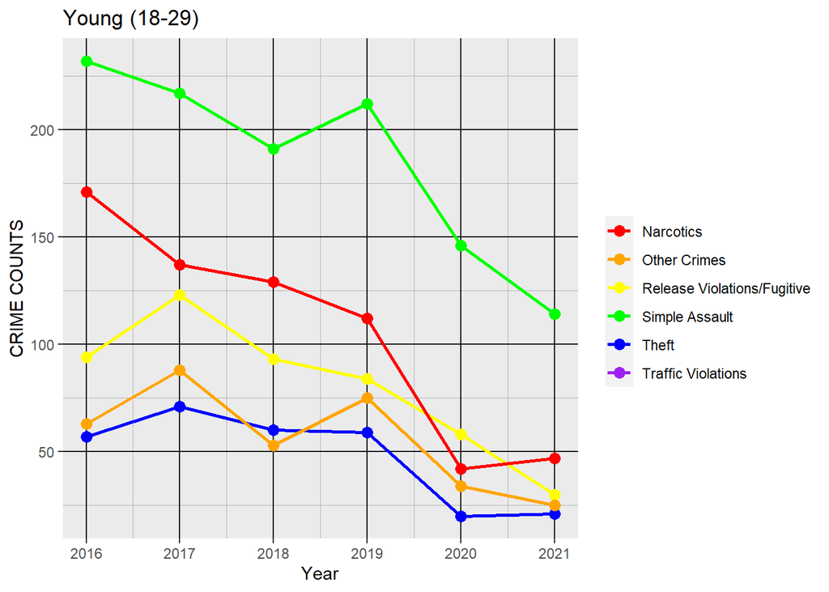

```r
plot_young
```

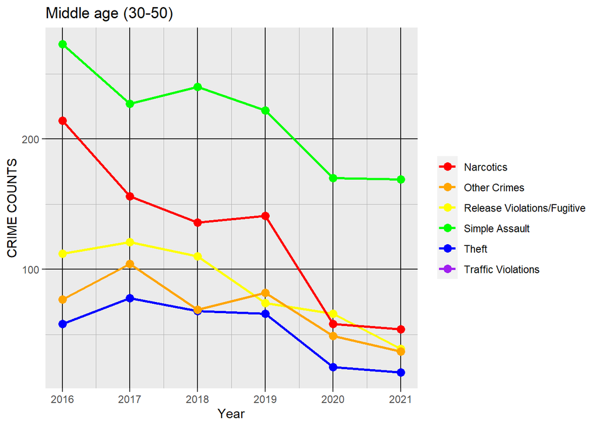

```r
plot_mid
```

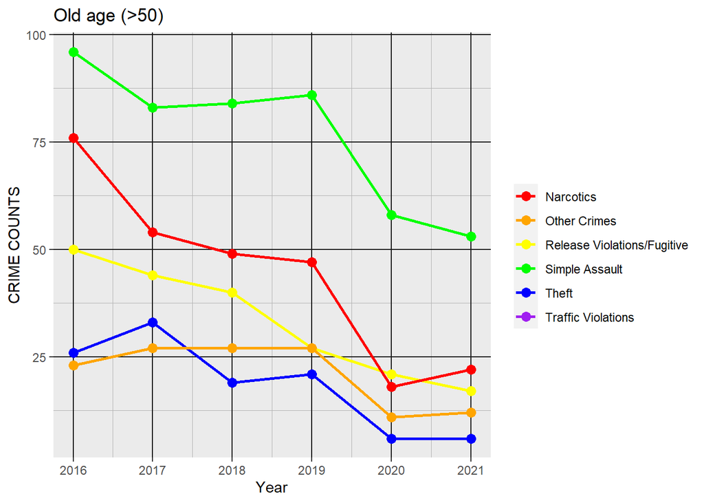

```r
plot_old
```

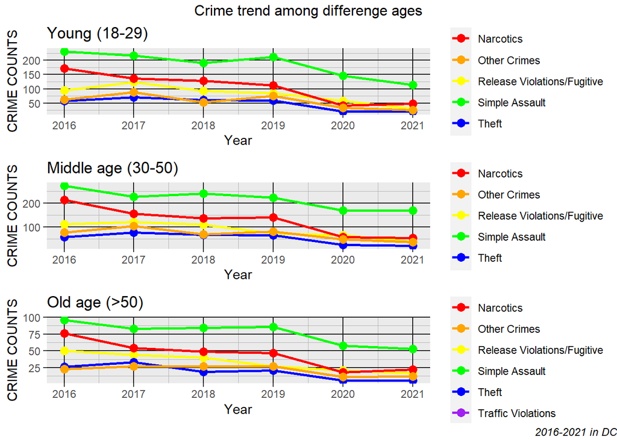

```r
library(gridExtra)
library(grid)
library(ggplot2)
library(lattice)
grid.arrange(
arrangeGrob(plot_young, plot_mid, plot_old, ncol=1, nrow=3),
  top = "Crime trend among differenge ages",
  bottom = textGrob(
    "2016-2021 in DC",
    gp = gpar(fontface = 3, fontsize = 9),
    hjust = 1,
    x = 1
  )
)
```

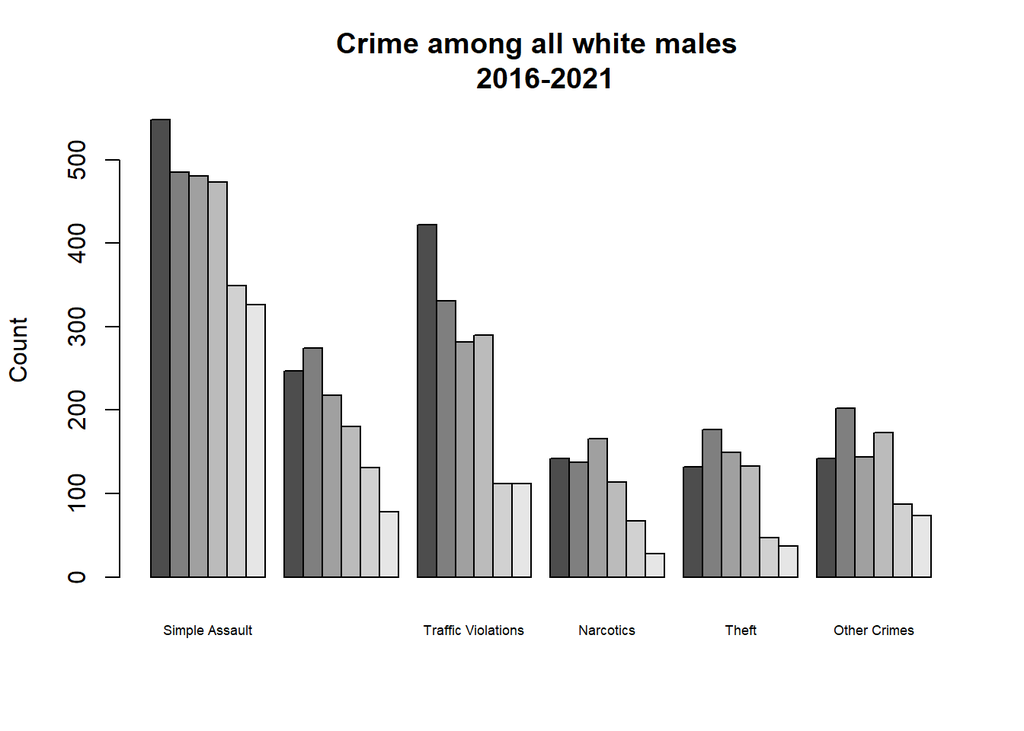

```r
barplot(as.matrix(DF_white_new)[,2:7],
        main="Crime among all white males \n 2016-2021",

        # setting y label only
        # because x-label will be our
        # barplots name
        ylab="Count",
         las=0, cex.names=0.55,
        # to plot the bars vertically
        beside=TRUE,
)
```

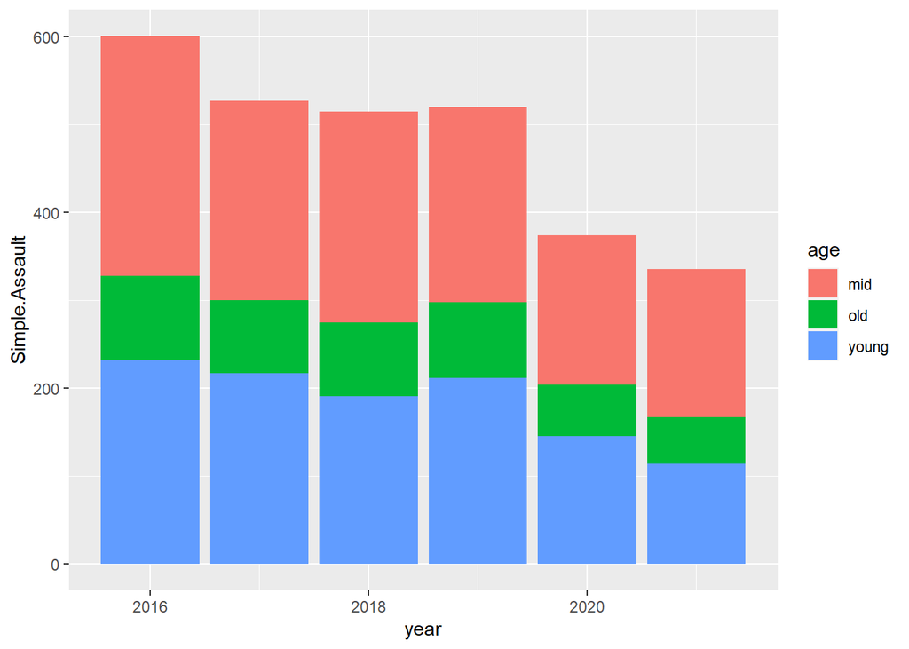

```r
head(DF_white_age2)
#ggplot(DF_white_age2,aes((Narcotics)))+geom_boxplot(aes(fill=age))




ggplot(DF_white_age2, aes(fill=age, y=Simple.Assault, x=year)) +
    geom_bar(position="stack", stat="identity")
```

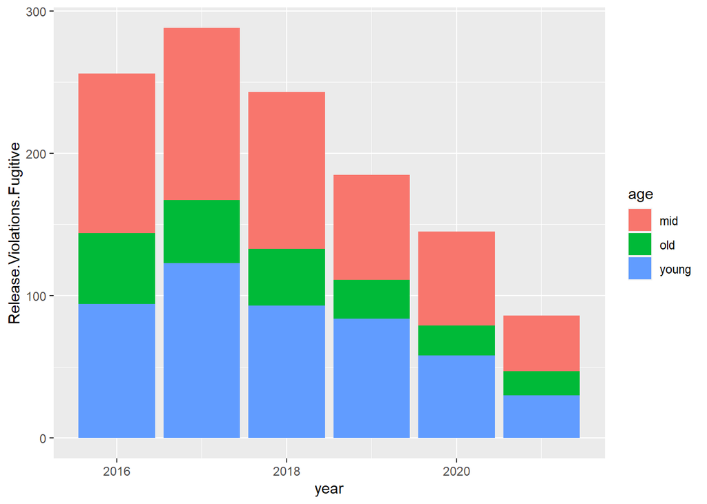

```r
ggplot(DF_white_age2, aes(fill=age, y=Release.Violations.Fugitive, x=year)) +
    geom_bar(position="stack", stat="identity")
```

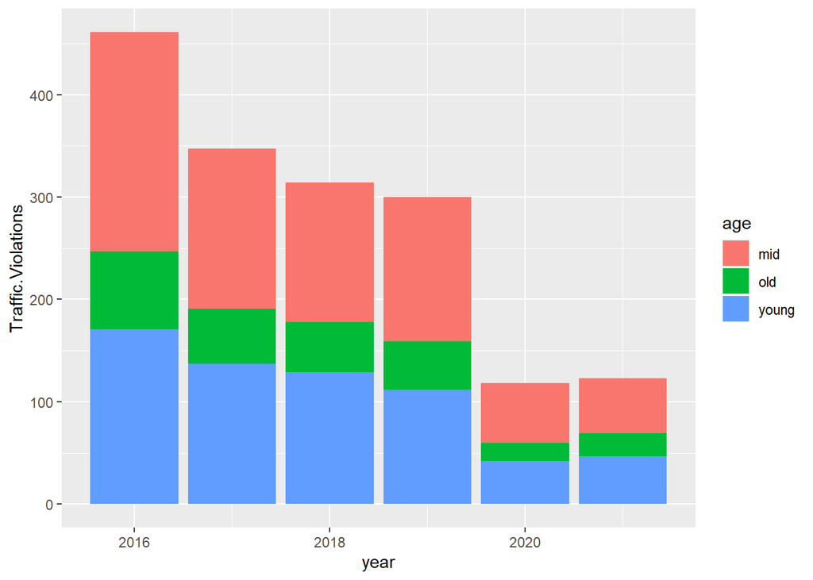

```r
ggplot(DF_white_age2, aes(fill=age, y=Traffic.Violations
, x=year)) +
    geom_bar(position="stack", stat="identity")
```

[figure not shown]

```r
ggplot(DF_white_age2, aes(fill=age, y=Narcotics, x=year)) +
    geom_bar(position="stack", stat="identity")
```

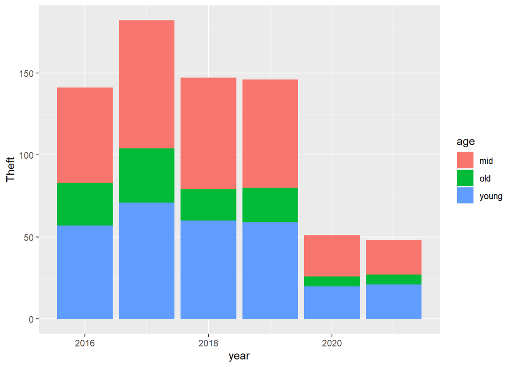

```r
ggplot(DF_white_age2, aes(fill=age, y=Theft, x=year)) +
    geom_bar(position="stack", stat="identity")
```

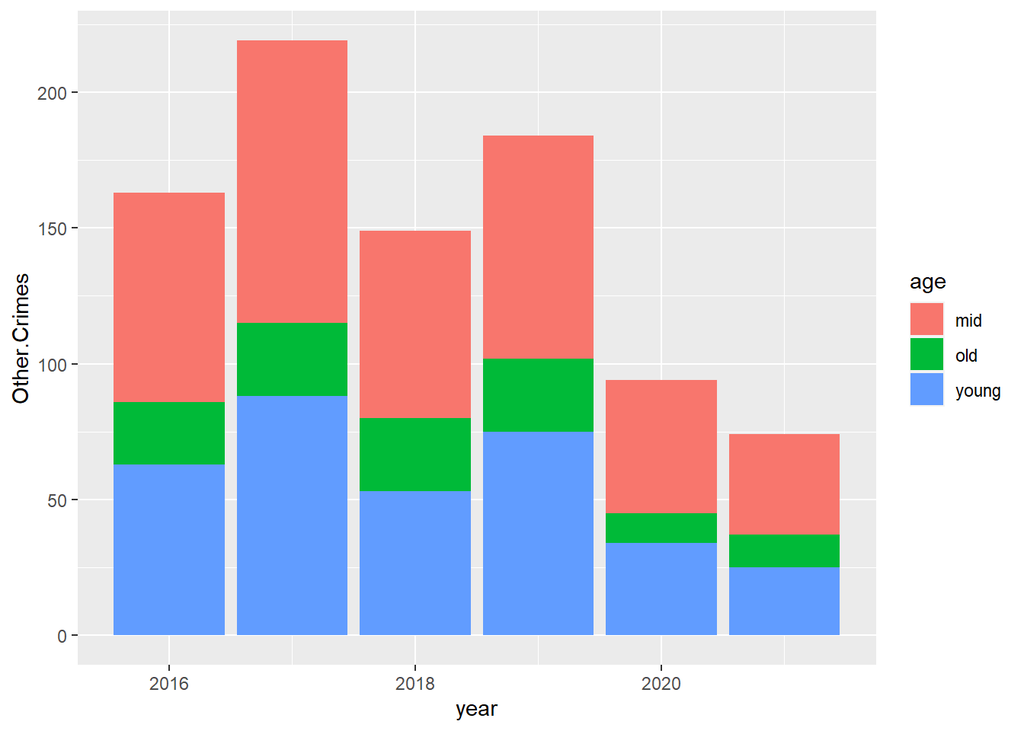

```r
ggplot(DF_white_age2, aes(fill=age, y=Other.Crimes
, x=year)) +
    geom_bar(position="stack", stat="identity")
```

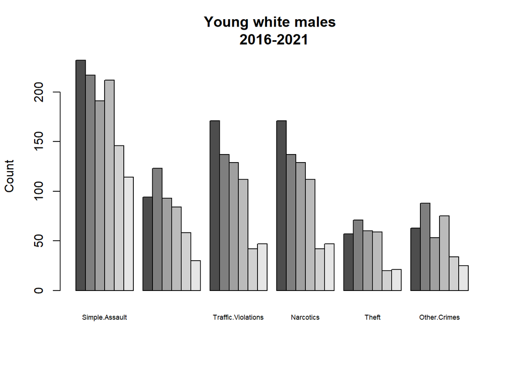

```r
bar_young<-barplot(as.matrix(DF_white_young[,2:7]),
        main="Young white males \n 2016-2021",

        # setting y label only
        # because x-label will be our
        # barplots name
        ylab="Count",
         las=0, cex.names=0.55,
        # to plot the bars vertically
        beside=TRUE,
)
```

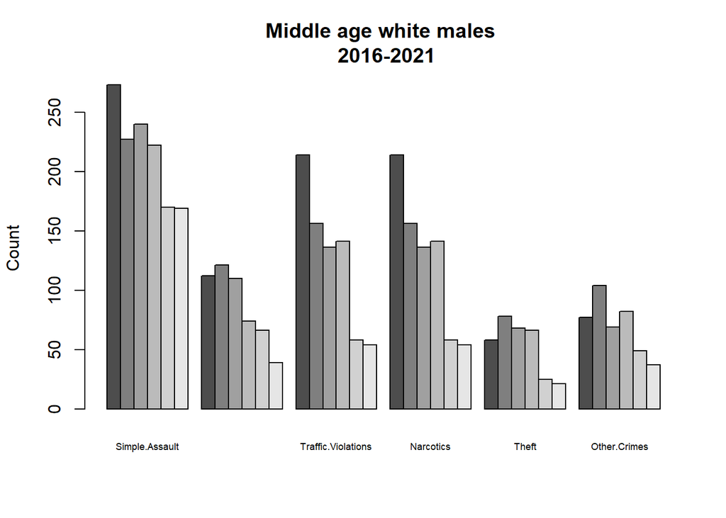

```r
bar_mid<-barplot(as.matrix(DF_white_mid[,2:7]),
        main="Middle age white males \n 2016-2021",

        # setting y label only
        # because x-label will be our
        # barplots name
        ylab="Count",
         las=0, cex.names=0.55,
        # to plot the bars vertically
        beside=TRUE,
)
```

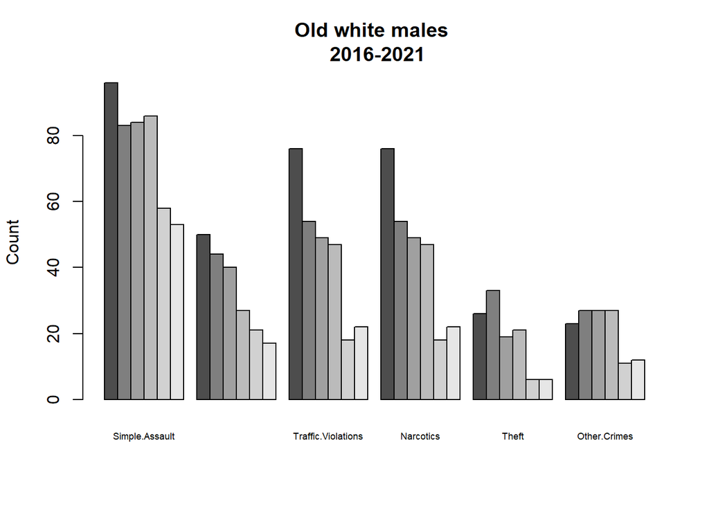

```r
bar_old<-barplot(as.matrix(DF_white_old[,2:7]),
        main="Old white males \n 2016-2021",

        # setting y label only
        # because x-label will be our
        # barplots name
        ylab="Count",
         las=0, cex.names=0.55,
        # to plot the bars vertically
        beside=TRUE,
)
```